# Nonlinear, Dynamic, and Linear Programming

Jie Xu (s181238)

# NLP1, Problem Formulation

The decision variables in part B are defined as follows:
$$\begin{array}{clc}
\hline
\text { Variables } & \text { Definition } & \text{ Type } \\
\hline
\mathrm{x}_{1} & \text { hours spent producing IPA } & \text{continuous} \\
\mathrm{x}_{2} & \text { hours spent producing Lager } & \text{continuous} \\
\hline
\end{array}$$

The problem can be formulated as:
$$\begin{align} \begin{split}
\max \quad & 15 \sqrt{x_{1}} + 16 \sqrt{x_{2}} \\
\text{s.t.} \quad & x_{1} + x_{2} \leq 120 \\
& x_{1}, x_{2} \in \mathbb{R}^+
\end{split} \end{align}$$

# NLP2, Convexity Analysis

Two parts in the function $L(x_{1}, x_{2}, \lambda)$ are monotonically increasing, so the function is strictly convex. (Its Hessian matrix is positive semidefinite for all possible values.) It is obvious that the decision variables belong to a convex set.

Point (1, 1) is a slater point, so the problem satisfies Slater’s condition. The strong duality holds.

# NLP3, Lagrangian Function

The Lagrangian function is:
$$\begin{align} \begin{split}
L(x_{1}, x_{2}, \lambda) = 15 \sqrt{x_{1}} + 16 \sqrt{x_{2}} - \lambda (x_{1} + x_{2} - 120)
\end{split} \end{align}$$
whose derivatives are:
$$\begin{align} \begin{split}
\frac{\partial L}{\partial x_{1}} &= \frac{15}{2 \sqrt{x_{1}}} - \lambda \\
\frac{\partial L}{\partial x_{2}} &= 8 / \sqrt{x_{2}} - \lambda \\
\frac{\partial L}{\partial \lambda} &= x_{1} + x_{2} - 120
\end{split} \end{align}$$

Also:
$$\begin{align}
x_1, x_2 \geq 0 \\
\lambda \geq 0
\end{align}$$

# NLP4, KKT Conditions

For a given nonlinear programming problem:
$$\begin{align}
\max \quad & f(\mathbf{x}) \\
\text{s.t.} \quad & g_{i}(\mathbf{x}) \leq b_{i} \quad \text{for } i = 1, 2, ..., m \\
& \mathbf{x} \geq \mathbf{0}
\end{align}$$
where $\mathbf{x} = \left(x_{1}, x_{2}, \ldots, x_{n}\right)$, The necessary condition for $\mathbf{x}^{*}$ being its critical point is that $\mathbf{x}^{*}$ satisfy all the following KKT conditions:
$$\begin{align}
\frac{\partial h}{\partial x_{j}} &\leq 0 \quad \text{for } j = 1, 2, \ldots, n \\
x^*_j \frac{\partial h}{\partial x_{j}} &= 0 \quad \text{for } j = 1, 2, \ldots, n \\
\frac{\partial h}{\partial \lambda_{i}} &\leq 0 \quad \text{for } i = 1, 2, \ldots, m \\
\lambda_{i} \frac{\partial h}{\partial \lambda_{i}} &= 0 \quad \text{for } i = 1, 2, \ldots, m \\
\mathbf{x}^{*} &\geq 0 \\
\boldsymbol{\lambda} &\geq 0
\end{align}$$
where the Lagrangian function $h(\mathbf{x}, \boldsymbol{\lambda})$ and its derivatives are:
$$\begin{align}
h(\mathbf{x}, \boldsymbol{\lambda}) &= f(\mathbf{x})-\sum_{i=1}^{m} \lambda_{i}\left[g_{i}(\mathbf{x})-b_{i}\right]
\end{align}$$

# NLP5, Solutions

Critical points can be calculated by the symbolic math toolbox in MATLAB:

```matlab
syms x1 x2 lbd
eq(1) = lbd * (x1 + x2 - 120) == 0;
eq(2) = x1 * (15/2/sqrt(x1) - lbd) == 0;
eq(3) = x2 * (8/sqrt(x2) - lbd) == 0;
sol = solve(eq)
```

Results are (0, 0, 0), (120, 0, 0.6847), (0, 120, 0.7303), and (56.133, 63.867, 1.0010), and corresponding values of the objective function are 0, 164.3168, 175.2712, and 240.2499. So the point (56.133, 63.867, 1.0010) is chosen as the optimal solution.
$$\begin{align}
x_{1} &= 56.133 \quad \text{so that } 3 \sqrt{x_{1}} \approx 22.5 \\
x_{2} &= 63.867 \quad \text{so that } 4 \sqrt{x_{2}} \approx 32 \\
\lambda &\approx 1 \\
15 \sqrt{x_{1}} + 16 \sqrt{x_{2}} &= 240.250 \\
\end{align}$$

So I would allocate 56.133 hours in total to produce 22 and half bottles of IPA, and 63.867 hours in total to produce 32 bottles of Lager. The obtained maximum revenue is 240.250.

# DP1, State Space Model

The shape of a suspended chain can be described and solved using dynamic programming. The chain is composed of $N$ identical segments, the length of which is $l$. The position of the end of some segment $i$ can be described by a vector $[z, y]_{i}^{T}$.

The equations to describe the dynamics of the chain are simplified to one dimensional unconstrained equation, and the angels are described in the Radian system. That is, For $i=0,1, \ldots N-1$, we have:
$$\begin{align}
\left[\begin{array}{l}{z} \\ {y}\end{array}\right]_{i+1} = f \left( \left[ \begin{array}{l}{z} \\ {y}\end{array} \right]_{i}, \left[ \begin{array}{l}{u} \\ {v}\end{array} \right]_{i} \right) &= \left[ \begin{array}{l}{z} \\ {y}\end{array} \right]_{i} + \left[ \begin{array}{l}{u} \\ {v}\end{array} \right]_{i} \\
= f \left( \left[ \begin{array}{l}{z} \\ {y}\end{array} \right]_{i}, \theta_{i} \right) &= \left[ \begin{array}{l}{z} \\ {y}\end{array} \right]_{i} + l \left[ \begin{array}{l}{\cos \left(\theta_{i} \right)} \\ {\sin \left(\theta_{i} \right)}\end{array} \right]
\end{align}$$

where two end points of the chain are:
$$\begin{align}
\left[ \begin{array}{l}{z} \\ {y}\end{array} \right]_{0} &= \left[ \begin{array}{l}{0} \\ {0}\end{array} \right] \\
\left[ \begin{array}{l}{z} \\ {y}\end{array} \right]_{N} &= \left[ \begin{array}{l}{h} \\ {0}\end{array} \right]
\end{align}$$

So the constraint $u_i^2 + v_i^2 = l^2$ is no longer needed. Notice that the angels are not constrained, but they can be estimated to be between $- 0.5 \pi$ and $0.5 \pi$.

# DP2, Formulation

With the new one dimensional unconstrained equation, the (steady state) potential energy can be used as the cost function:
$$\begin{align}
J &= \sum_{i=0}^{N-1} \frac{1}{2} m g \left( y_{i} + y_{i+1} \right) \\
&= \sum_{i=0}^{N-1} \left[ m g y_{i} + \frac{1}{2} m g l sin(\theta_i) \right]
\end{align}$$
where the scalar $\phi$, $L$ in the standard form of the cost function can be expressed by the following equations with $N$ fixed:
$$\begin{align}
\phi \left( \left[ \begin{array}{l}{z} \\ {y} \end{array} \right]_{N} \right) &= 0 \\
L \left( \left[ \begin{array}{l}{z} \\ {y}\end{array} \right]_{i}, \theta_i \right) &= m g y_{i} + \frac{1}{2} m g l sin(\theta_i)
\end{align}$$

The deterministic dynamic programming can be summarised as:
$$\begin{align}
\min_{\theta_0, \theta_1, ..., \theta_{N-1}} \quad & J = \sum_{i=0}^{N-1} \left[ m g y_{i} + \frac{1}{2} m g l sin(\theta_i) \right] \\
\text{s.t.} \quad & \left[\begin{array}{l}{z} \\ {y}\end{array}\right]_{i+1} = \left[ \begin{array}{l}{z} \\ {y}\end{array} \right]_{i} + l \left[ \begin{array}{l}{\cos \left(\theta_{i} \right)} \\ {\sin \left(\theta_{i} \right)}\end{array} \right] \quad \text{for } i = 0, 1, ..., N-1 \\
& \left[ \begin{array}{l}{z} \\ {y}\end{array} \right]_{0} = \left[ \begin{array}{l}{0} \\ {0}\end{array} \right] \\
& \left[ \begin{array}{l}{z} \\ {y}\end{array} \right]_{N} = \left[ \begin{array}{l}{h} \\ {0}\end{array} \right]
\end{align}$$
where $z_1, z_2, ..., z_{N-1}$ and $y_1, y_2, ..., y_{N-1}$ are decision variables as well, but they are determined once $\theta_0, \theta_1, ..., \theta_{N-1}$ are chosen.

# DP3, Euler-Lagrange Equations

The $i$-th Hamiltonian function of can be expressed as:

$$H_i \left(z_i, y_i, \theta_i, \lambda^z_{i+1}, \lambda^y_{i+1} \right) = m g y_{i} + \frac{1}{2} m g l \sin(\theta_i) + \lambda^z_{i+1} \left[ z_{i} + l \cos \left(\theta_{i} \right) \right] + \lambda^y_{i+1} \left[ y_{i} + l \sin \left(\theta_{i} \right) \right]$$

Hence the set of Euler-Lagrange equations can be expressed by the following five equations:

$$\begin{align}
z_{i+1} &= z_{i} + l \cos \left(\theta_{i} \right) \\
y_{i+1} &= y_{i} + l \sin \left(\theta_{i} \right) \\
\lambda^{z}_{i} &= \lambda^z_{i+1} \\
\lambda^{y}_{i} &= m g + \lambda^y_{i+1} \\
0 &= \left[ \frac{1}{2} m g + \lambda^y_{i+1} \right] \cos(\theta_i) - \lambda^z_{i+1} \sin(\theta_i)
\end{align}$$

where the boundary conditions are:

$$\begin{align}
\left[ \begin{array}{l}{z} \\ {y}\end{array} \right]_{0} &= \left[ \begin{array}{l}{0} \\ {0}\end{array} \right] \\
\left[ \begin{array}{l}{z} \\ {y}\end{array} \right]_{N} &= \left[ \begin{array}{l}{h} \\ {0}\end{array} \right] \\
\left[ \begin{array}{l}{\lambda_z} \\ {\lambda_y} \\ {\theta} \end{array} \right]_{N} &= \left[ \begin{array}{l}{\nu_z} \\ {\nu_y} \\ {1} \end{array} \right] \\
\end{align}$$

# DP4, Solution

Numerical method can be used to find the optimal values. The calculate procedure for iterations can be expressed by the following five equations:

$$\begin{align}
\lambda^z_{i+1} &= \lambda^{z}_{i} \\
\lambda^y_{i+1} &= \lambda^{y}_{i} - m g \\
\theta_i &= \arctan \left[ \left( \lambda^y_{i+1} + \frac{1}{2} m g \right) / \lambda^z_{i+1} \right] \\
z_{i+1} &= z_{i} + l \cos \left(\theta_{i} \right) \\
y_{i+1} &= y_{i} + l \sin \left(\theta_{i} \right) \\
\end{align}$$

When $h = 6, L = 10, M = 14, N = 6$, the value of the costate vector at 0, $\left[ \lambda^{z}_{i}, \lambda^{y}_{i} \right]^{T}_{0}$, is $[-22.3645, 68.6700]$.

When $h = 6, L = 10, M = 14, N = 100$, the value of the costate vector at 0, $\left[ \lambda^{z}_{i}, \lambda^{y}_{i} \right]^{T}_{0}$, is $[-22.4092, 68.6700]$.

The two results can be visualised by the figure 1:

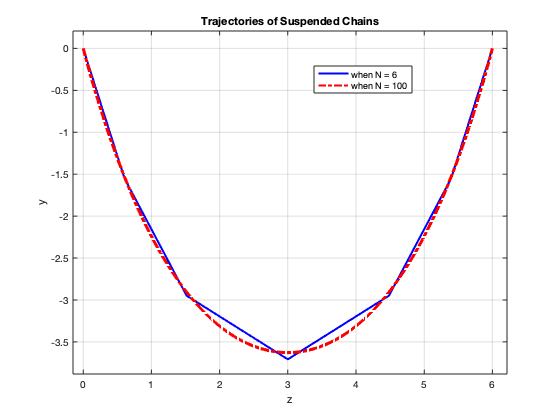

Result.

# LP1, Problem Formulation

A integer variable $x_4$ indicating the number of cabin events per year is introduced. All variables are defined as integer variables, though it seems that it is not necessary:
$$\begin{array}{clc}
\hline \text { Variables } & \text { Definition } & \text { is.integer } \\
\hline \mathrm{x}_{1,1} & \text { how many days I spend on trees per year } & \mathrm{Y} \\
\mathrm{x}_{1,2} & \text { how many days I spend on hunting per year } & \mathrm{Y} \\
\mathrm{x}_{1,3} & \text { how many days I spend on managing cabin events per year } & \mathrm{Y} \\
\mathrm{x}_{2,1} & \text { how many days uncle spend on tree per year } & \mathrm{Y} \\
\mathrm{x}_{2,2} & \text { how many days uncle spend on hunting per year } & \mathrm{Y} \\
\mathrm{x}_{2,3} & \text { how many days uncle spend on managing cabin events per year } & \mathrm{Y} \\
\mathrm{x}_{3,1} & \text { how many days cousin spend on tree per year } & \mathrm{Y} \\
\mathrm{x}_{3,2} & \text { how many days cousin spend on hunting per year } & \mathrm{Y} \\
\mathrm{x}_{3,3} & \text { how many days cousin spend on managing cabin events per year } & \mathrm{Y} \\
\mathrm{x}_{4} & \text { Num of cabin events per year } & \mathrm{Y} \\
\hline
\end{array}$$

The problem can be formualted as follows:
$$\begin{align}
\max \quad & 1000 \left(x_{1,1} + x_{2,1} + x_{3,1}\right) + 750 \left(x_{1,2} + x_{2,2} + x_{3,2} \right) + 2000 x_{4} \\
\text{s.t.} \quad & x_{1,1} + x_{1,2} + x_{1,3} \leq 40 \qquad \text{(available days of me)} \\
& x_{2,1} + x_{2,2} + x_{2,3} \leq 50 \qquad \text{(available days of uncle)} \\
& x_{3,1} + x_{3,2} + x_{3,3} \leq 60 \qquad \text{(available days of cousin)} \\
& x_{1,1} \geq 20 \qquad \text{(I like harvesting trees)} \\
& x_{2,1} = 0 \qquad \text{(uncle cannot do because of his back issues)} \\
& x_{2,2} \geq 20 \qquad \text{(uncle likes hunting)} \\
& x_{2,3} \leq 50 / 3 \qquad \text{(uncle doesn't likes managing cabin)} \\
& x_{3,3} \geq 3\left(x_{1,3}+x_{2,3}\right) \qquad \text{(cousin likes managing cabin)} \\
& x_{1,2} + x_{2,2} + x_{3,2} \leq 30 \qquad \text{(hunting restrictions)} \\
& x_{1, 1} + x_{2, 1} + x_{3, 1} \leq 80 \qquad \text{(trees restrictions)} \\
& x_{4} \leq 20 \qquad \text{(cabin restrictions)} \\
& x_{1,3} + x_{2,3} + x_{3,3} \geq 2 x_{4} \qquad \text{(workdays for cabin management)} \\
& x_{1,1}, x_{1,2}, x_{1,3}, x_{2,1}, x_{2,2}, x_{2,3}, x_{3,1}, x_{3,2}, x_{3,3}, x_{4} \in \mathbb{Z}^{+}
\end{align}$$

I will relax the problem to a linear programming problem first. If I get a solution with all variable outcomes being integer, then it is the solution to the original integer programming problem. If not, branch-and-cut algorithm has to be used to solve the original integer programming problem iteratively.

# LP2, Simplification

$$\begin{array}{clc}
\hline \text { Variables } & \text { Definition } & \text { is.integer } \\
\hline x_{1,1} & \text { how many day I spend on tree per year } & \mathrm{F} \\
x_{1,2} & \text { how many days I spend on hunting per year } & \mathrm{F} \\
x_{1,3} & \text { how many cabin events by me per year } & \mathrm{F} \\
x_{2,1} & \text { how many days uncle spend on tree per year } & \mathrm{F} \\
x_{2,2} & \text { how many days uncle spend on hunting per year } & \mathrm{F} \\
x_{2,3} & \text { how many cabin events by uncle per year } & \mathrm{F} \\
x_{3,1} & \text { how many days cousin spend on tree per year } & \mathrm{F} \\
x_{3,2} & \text { how many days cousin spend on hunting per year } & \mathrm{F} \\
x_{3,3} & \text { how many cabin events by cousin per year } & \mathrm{F} \\
\hline
\end{array}$$

$$\begin{align}
\max \quad & 1000 \left(x_{1,1} + x_{2,1} + x_{3,1}\right) + 750 \left(x_{1,2} + x_{2,2} + x_{3,2} \right) + 2000 (x_{1,3} + x_{2,3} + x_{3,3}) \\
\text{s.t.} \quad & x_{1,1} + x_{1,2} + 2 x_{1,3} \leq 40 \qquad \text{(available days of me)} \\
& x_{2,1} + x_{2,2} + 2 x_{2,3} \leq 50 \qquad \text{(available days of uncle)} \\
& x_{3,1} + x_{3,2} + 2 x_{3,3} \leq 60 \qquad \text{(available days of cousin)} \\
& x_{1,1} \geq 20 \qquad \text{(I like harvesting trees)} \\
& x_{2,1} = 0 \qquad \text{(uncle cannot do because of his back issues)} \\
& x_{2,2} \geq 20 \qquad \text{(uncle likes hunting)} \\
& x_{2,3} \leq 50 / 3 \qquad \text{(uncle doesn't likes managing cabin)} \\
& x_{3,3} \geq 3\left(x_{1,3}+x_{2,3}\right) \qquad \text{(cousin likes managing cabin)} \\
& x_{1,2} + x_{2,2} + x_{3,2} \leq 30 \qquad \text{(hunting restrictions)} \\
& x_{1, 1} + x_{2, 1} + x_{3, 1} \leq 80 \qquad \text{(trees restrictions)} \\
& x_{1,3} + x_{2,3} + x_{3,3} \leq 20 \qquad \text{(cabin restrictions)} \\
& x_{1,1}, x_{1,2}, x_{1,3}, x_{2,1}, x_{2,2}, x_{2,3}, x_{3,1}, x_{3,2}, x_{3,3} \geq 0
\end{align}$$

# LP3, in Augmented Form

$$\begin{align}
\max \quad & 1000 \left(x_{1,1} + x_{2,1} + x_{3,1}\right) + 750 \left(x_{1,2} + x_{2,2} + x_{3,2} \right) + 2000 (x_{1,3} + x_{2,3} + x_{3,3}) \\
\text{s.t.} \quad & x_{1,1} + x_{1,2} + 2 x_{1,3} + y_1 = 40 \\
& x_{2,1} + x_{2,2} + 2 x_{2,3} + y_2 = 50 \\
& x_{3,1} + x_{3,2} + 2 x_{3,3} + y_3 = 60 \\
& x_{1,2} + x_{2,2} + x_{3,2} + y_4 = 30 \\
& x_{1, 1} + x_{2, 1} + x_{3, 1} + y_5 = 80 \\
& x_{2,3} + y_6 = 50 / 3 \\
& x_{1,3} + x_{2,3} + x_{3,3} + y_7 = 20 \\
& x_{1,1} + \bar{y}_8 - y_9 = 20 \\
& x_{2,1} + \bar{y}_{10} = 0 \\
& x_{2,2} + \bar{y}_{11} - y_{12} = 20 \\
& - x_{3,3} + 3 x_{1,3} + 3 x_{2,3} + y_{13} = 0 \\
& x_{1,1}, x_{1,2}, x_{1,3}, x_{2,1}, x_{2,2}, x_{2,3}, x_{3,1}, x_{3,2}, x_{3,3} \geq 0 \\
& y_{1}, y_{2}, y_{3}, y_{4}, y_{5}, y_{6}, y_{7}, \bar{y}_{8}, y_{9}, \bar{y}_{10}, \bar{y}_{11}, y_{12}, y_{13} \geq 0
\end{align}$$
where $\bar{y}_{8}$, $\bar{y}_{10}$, $\bar{y}_{11}$ are artificial variables, and $y_{9}$ and $y_{12}$ are surplus variables. The two-phase simplex method has to be used:

- First phase: $\max Z = \bar{y}_{8} + \bar{y}_{10} + \bar{y}_{11}$
- Second phase: $\max Z = 1000 \left(x_{1,1} + x_{2,1} + x_{3,1}\right) + 750 \left(x_{1,2} + x_{2,2} + x_{3,2} \right) + 2000 (x_{1,3} + x_{2,3} + x_{3,3})$

# LP4, the First Phase

The first phase is to maximise the following problem:
$$\begin{align}
\max \quad & Z = \bar{y}_{8} + \bar{y}_{10} + \bar{y}_{11} \\
\text{s.t.} \quad & x_{1,1} + x_{1,2} + 2 x_{1,3} + y_1 = 40 \\
& x_{2,1} + x_{2,2} + 2 x_{2,3} + y_2 = 50 \\
& x_{3,1} + x_{3,2} + 2 x_{3,3} + y_3 = 60 \\
& x_{1,2} + x_{2,2} + x_{3,2} + y_4 = 30 \\
& x_{1, 1} + x_{2, 1} + x_{3, 1} + y_5 = 80 \\
& x_{2,3} + y_6 = 50 / 3 \\
& x_{1,3} + x_{2,3} + x_{3,3} + y_7 = 20 \\
& x_{1,1} + \bar{y}_8 - y_9 = 20 \\
& x_{2,1} + \bar{y}_{10} = 0 \\
& x_{2,2} + \bar{y}_{11} - y_{12} = 20 \\
& - x_{3,3} + 3 x_{1,3} + 3 x_{2,3} + y_{13} = 0 \\
& x_{1,1}, x_{1,2}, x_{1,3}, x_{2,1}, x_{2,2}, x_{2,3}, x_{3,1}, x_{3,2}, x_{3,3} \geq 0 \\
& y_{1}, y_{2}, y_{3}, y_{4}, y_{5}, y_{6}, y_{7}, \bar{y}_{8}, y_{9}, \bar{y}_{10}, \bar{y}_{11}, y_{12}, y_{13} \geq 0
\end{align}$$
which can be represented by the following tableau:
$$\begin{array}{ccccccccccccccccccc}
\hline
\mathrm{i} & \mathrm{BV} & \mathrm{Z} & {x}_{1,1} & {x}_{1,2} & {x}_{1,3} & {x}_{2,1} & {x}_{2,2} & {x}_{2,3} & {x}_{3,1} & {x}_{3,2} & {x}_{3,3} & {y}_{1} & {y}_{2} & {y}_{3} & {y}_{4} & {y}_{5} & {y}_{6} & {y}_{7} & \bar{y}_{8} & {y}_{9} & \bar{y}_{10} & \bar{y}_{11} & {y}_{12} & {y}_{13} & \mathrm{b} \\
\hline
0 & \mathrm{Z} & 1 & 0 & 0 & 0 & 0 & 0 & 0 & 0 & 0 & 0 & 0 & 0 & 0 & 0 & 0 & 0 & 0 & -1 & 0 & -1 & -1 & 0 & 0 & 0 \\
1 & y_{1} & 0 & 1 & 1 & 2 & 0 & 0 & 0 & 0 & 0 & 0 & 1 & 0 & 0 & 0 & 0 & 0 & 0 & 0 & 0 & 0 & 0 & 0 & 0 & 40 \\
2 & y_{2} & 0 & 0 & 0 & 0 & 1 & 1 & 2 & 0 & 0 & 0 & 0 & 1 & 0 & 0 & 0 & 0 & 0 & 0 & 0 & 0 & 0 & 0 & 0 & 50 \\
3 & y_{3} & 0 & 0 & 0 & 0 & 0 & 0 & 0 & 1 & 1 & 2 & 0 & 0 & 1 & 0 & 0 & 0 & 0 & 0 & 0 & 0 & 0 & 0 & 0 & 60 \\
4 & y_{4} & 0 & 0 & 1 & 0 & 0 & 1 & 0 & 0 & 1 & 0 & 0 & 0 & 0 & 1 & 0 & 0 & 0 & 0 & 0 & 0 & 0 & 0 & 0 & 30 \\
5 & y_{5} & 0 & 1 & 0 & 0 & 1 & 0 & 0 & 1 & 0 & 0 & 0 & 0 & 0 & 0 & 1 & 0 & 0 & 0 & 0 & 0 & 0 & 0 & 0 & 80 \\
6 & y_{6} & 0 & 0 & 0 & 0 & 0 & 0 & 1 & 0 & 0 & 0 & 0 & 0 & 0 & 0 & 0 & 1 & 0 & 0 & 0 & 0 & 0 & 0 & 0 & 50/3 \\
7 & y_{7} & 0 & 0 & 0 & 1 & 0 & 0 & 1 & 0 & 0 & 1 & 0 & 0 & 0 & 0 & 0 & 0 & 1 & 0 & 0 & 0 & 0 & 0 & 0 & 20 \\
8 & \bar{y}_{8} & 0 & 1 & 0 & 0 & 0 & 0 & 0 & 0 & 0 & 0 & 0 & 0 & 0 & 0 & 0 & 0 & 0 & 1 & -1 & 0 & 0 & 0 & 0 & 20 \\
9 & \bar{y}_{10} & 0 & 0 & 0 & 0 & 1 & 0 & 0 & 0 & 0 & 0 & 0 & 0 & 0 & 0 & 0 & 0 & 0 & 0 & 0 & 1 & 0 & 0 & 0 & 0 \\
10 & \bar{y}_{11} & 0 & 0 & 0 & 0 & 0 & 1 & 0 & 0 & 0 & 0 & 0 & 0 & 0 & 0 & 0 & 0 & 0 & 0 & 0 & 0 & 1 & -1 & 0 & 20 \\
11 & y_{13} & 0 & 0 & 0 & 3 & 0 & 0 & 3 & 0 & 0 & -1 & 0 & 0 & 0 & 0 & 0 & 0 & 0 & 0 & 0 & 0 & 0 & 0 & 1 & 0 \\
\hline
\end{array}$$

# LP5, To Make Basis Variables in Row `0` all 0

Coefficients for basis variables, $y_{1}$, $y_{2}$, $y_{3}$, $y_{4}$, $y_{5}$, $y_{6}$, $y_{7}$, $\bar{y}_{8}$, $\bar{y}_{10}$, $\bar{y}_{11}$, and $y_{13}$ in the tableau must be 0. In contrast, those for ${y}_{9}$, and ${y}_{12}$ can be larger or smaller than 0.

So, coefficients in row `0` are added with coefficients in row `8`, row `9` and row `10`
$$\begin{array}{ccccccccccccccccccc}
\hline
\mathrm{i} & \mathrm{BV} & \mathrm{Z} & {x}_{1,1} & {x}_{1,2} & {x}_{1,3} & {x}_{2,1} & {x}_{2,2} & {x}_{2,3} & {x}_{3,1} & {x}_{3,2} & {x}_{3,3} & {y}_{1} & {y}_{2} & {y}_{3} & {y}_{4} & {y}_{5} & {y}_{6} & {y}_{7} & \bar{y}_{8} & {y}_{9} & \bar{y}_{10} & \bar{y}_{11} & {y}_{12} & {y}_{13} & \mathrm{b} \\
\hline
0 & \mathrm{Z} & 1 & 1 & 0 & 0 & 1 & 1 & 0 & 0 & 0 & 0 & 0 & 0 & 0 & 0 & 0 & 0 & 0 & 0 & -1 & 0 & 0 & -1 & 0 & 40 \\
1 & y_{1} & 0 & 1 & 1 & 2 & 0 & 0 & 0 & 0 & 0 & 0 & 1 & 0 & 0 & 0 & 0 & 0 & 0 & 0 & 0 & 0 & 0 & 0 & 0 & 40 \\
2 & y_{2} & 0 & 0 & 0 & 0 & 1 & 1 & 2 & 0 & 0 & 0 & 0 & 1 & 0 & 0 & 0 & 0 & 0 & 0 & 0 & 0 & 0 & 0 & 0 & 50 \\
3 & y_{3} & 0 & 0 & 0 & 0 & 0 & 0 & 0 & 1 & 1 & 2 & 0 & 0 & 1 & 0 & 0 & 0 & 0 & 0 & 0 & 0 & 0 & 0 & 0 & 60 \\
4 & y_{4} & 0 & 0 & 1 & 0 & 0 & 1 & 0 & 0 & 1 & 0 & 0 & 0 & 0 & 1 & 0 & 0 & 0 & 0 & 0 & 0 & 0 & 0 & 0 & 30 \\
5 & y_{5} & 0 & 1 & 0 & 0 & 1 & 0 & 0 & 1 & 0 & 0 & 0 & 0 & 0 & 0 & 1 & 0 & 0 & 0 & 0 & 0 & 0 & 0 & 0 & 80 \\
6 & y_{6} & 0 & 0 & 0 & 0 & 0 & 0 & 1 & 0 & 0 & 0 & 0 & 0 & 0 & 0 & 0 & 1 & 0 & 0 & 0 & 0 & 0 & 0 & 0 & 50/3 \\
7 & y_{7} & 0 & 0 & 0 & 1 & 0 & 0 & 1 & 0 & 0 & 1 & 0 & 0 & 0 & 0 & 0 & 0 & 1 & 0 & 0 & 0 & 0 & 0 & 0 & 20 \\
8 & \bar{y}_{8} & 0 & 1 & 0 & 0 & 0 & 0 & 0 & 0 & 0 & 0 & 0 & 0 & 0 & 0 & 0 & 0 & 0 & 1 & -1 & 0 & 0 & 0 & 0 & 20 \\
9 & \bar{y}_{10} & 0 & 0 & 0 & 0 & 1 & 0 & 0 & 0 & 0 & 0 & 0 & 0 & 0 & 0 & 0 & 0 & 0 & 0 & 0 & 1 & 0 & 0 & 0 & 0 \\
10 & \bar{y}_{11} & 0 & 0 & 0 & 0 & 0 & 1 & 0 & 0 & 0 & 0 & 0 & 0 & 0 & 0 & 0 & 0 & 0 & 0 & 0 & 0 & 1 & -1 & 0 & 20 \\
11 & y_{13} & 0 & 0 & 0 & 3 & 0 & 0 & 3 & 0 & 0 & -1 & 0 & 0 & 0 & 0 & 0 & 0 & 0 & 0 & 0 & 0 & 0 & 0 & 1 & 0 \\
\hline
\end{array}$$
Then, minimum ratio tests and Gaussian elimination has to be used to convert all coefficients in row `0` larger than 0.

# LP6, Illustration of Minimum Ratio Test

The entering column can be the one with $x_{1, 1}$, because absolute values of coefficients in columns $x_{1, 1}$, $x_{2, 1}$, $x_{2, 2}$ are the same.

Then the row with minimum ratio of $b / x_{1, 1}$ is chosen:
$$\begin{array}{ccc}
\hline
i & \mathrm{BV} & x_{1, 1} & b & \mathrm{ratio} \\
\hline
1 & y_{1} & 1 & 40 & 40 \\
5 & y_5 & 1 & 80 & 80 \\
8 & \bar{y}_8 & 1 & 20 & 20 \\
\hline
\end{array}$$
Then Gausian elimination is used to create a new tableau.

# LP7, Illustration of Gausian Elimination

Row `0`, row `1`, and row `5` are all minus the coefficients in row `8`:
$$\begin{array}{ccc|c|ccccccccccccccc}
\hline
\mathrm{i} & \mathrm{BV} & \mathrm{Z} & {x}_{1,1} & {x}_{1,2} & {x}_{1,3} & {x}_{2,1} & {x}_{2,2} & {x}_{2,3} & {x}_{3,1} & {x}_{3,2} & {x}_{3,3} & {y}_{1} & {y}_{2} & {y}_{3} & {y}_{4} & {y}_{5} & {y}_{6} & {y}_{7} & \bar{y}_{8} & {y}_{9} & \bar{y}_{10} & \bar{y}_{11} & {y}_{12} & {y}_{13} & \mathrm{b} \\
\hline
0 & \mathrm{Z} & 1 & 0 & 0 & 0 & 1 & 1 & 0 & 0 & 0 & 0 & 0 & 0 & 0 & 0 & 0 & 0 & 0 & -1 & 0 & 0 & 0 & -1 & 0 & 20 \\
1 & y_{1} & 0 & 0 & 1 & 2 & 0 & 0 & 0 & 0 & 0 & 0 & 1 & 0 & 0 & 0 & 0 & 0 & 0 & -1 & 1 & 0 & 0 & 0 & 0 & 20 \\
2 & y_{2} & 0 & 0 & 0 & 0 & 1 & 1 & 2 & 0 & 0 & 0 & 0 & 1 & 0 & 0 & 0 & 0 & 0 & 0 & 0 & 0 & 0 & 0 & 0 & 50 \\
3 & y_{3} & 0 & 0 & 0 & 0 & 0 & 0 & 0 & 1 & 1 & 2 & 0 & 0 & 1 & 0 & 0 & 0 & 0 & 0 & 0 & 0 & 0 & 0 & 0 & 60 \\
4 & y_{4} & 0 & 0 & 1 & 0 & 0 & 1 & 0 & 0 & 1 & 0 & 0 & 0 & 0 & 1 & 0 & 0 & 0 & 0 & 0 & 0 & 0 & 0 & 0 & 30 \\
5 & y_{5} & 0 & 0 & 0 & 0 & 1 & 0 & 0 & 1 & 0 & 0 & 0 & 0 & 0 & 0 & 1 & 0 & 0 & -1 & 1 & 0 & 0 & 0 & 0 & 60 \\
6 & y_{6} & 0 & 0 & 0 & 0 & 0 & 0 & 1 & 0 & 0 & 0 & 0 & 0 & 0 & 0 & 0 & 1 & 0 & 0 & 0 & 0 & 0 & 0 & 0 & 50/3 \\
7 & y_{7} & 0 & 0 & 0 & 1 & 0 & 0 & 1 & 0 & 0 & 1 & 0 & 0 & 0 & 0 & 0 & 0 & 1 & 0 & 0 & 0 & 0 & 0 & 0 & 20 \\
\hline
8 & \bar{y}_{8} & 0 & 1 & 0 & 0 & 0 & 0 & 0 & 0 & 0 & 0 & 0 & 0 & 0 & 0 & 0 & 0 & 0 & 1 & -1 & 0 & 0 & 0 & 0 & 20 \\
\hline
9 & \bar{y}_{10} & 0 & 0 & 0 & 0 & 1 & 0 & 0 & 0 & 0 & 0 & 0 & 0 & 0 & 0 & 0 & 0 & 0 & 0 & 0 & 1 & 0 & 0 & 0 & 0 \\
10 & \bar{y}_{11} & 0 & 0 & 0 & 0 & 0 & 1 & 0 & 0 & 0 & 0 & 0 & 0 & 0 & 0 & 0 & 0 & 0 & 0 & 0 & 0 & 1 & -1 & 0 & 20 \\
11 & y_{13} & 0 & 0 & 0 & 3 & 0 & 0 & 3 & 0 & 0 & -1 & 0 & 0 & 0 & 0 & 0 & 0 & 0 & 0 & 0 & 0 & 0 & 0 & 1 & 0 \\
\hline
\end{array}$$
Repeat the minimum ratio test and Gausian elimination until all coefficients in row `0` larger than 0.

# LP8, the Second Phase

The second phase is to maximise the following problem:
$$\begin{align}
\max \quad & 1000 \left(x_{1,1} + x_{2,1} + x_{3,1}\right) + 750 \left(x_{1,2} + x_{2,2} + x_{3,2} \right) + 2000 (x_{1,3} + x_{2,3} + x_{3,3}) \\
\text{s.t.} \quad & x_{1,1} + x_{1,2} + 2 x_{1,3} + y_1 = 40 \\
& x_{2,1} + x_{2,2} + 2 x_{2,3} + y_2 = 50 \\
& x_{3,1} + x_{3,2} + 2 x_{3,3} + y_3 = 60 \\
& x_{1,2} + x_{2,2} + x_{3,2} + y_4 = 30 \\
& x_{1, 1} + x_{2, 1} + x_{3, 1} + y_5 = 80 \\
& x_{2,3} + y_6 = 50 / 3 \\
& x_{1,3} + x_{2,3} + x_{3,3} + y_7 = 20 \\
& x_{1,1} + \bar{y}_8 - y_9 = 20 \\
& x_{2,1} + \bar{y}_{10} = 0 \\
& x_{2,2} + \bar{y}_{11} - y_{12} = 20 \\
& - x_{3,3} + 3 x_{1,3} + 3 x_{2,3} + y_{13} = 0 \\
& x_{1,1}, x_{1,2}, x_{1,3}, x_{2,1}, x_{2,2}, x_{2,3}, x_{3,1}, x_{3,2}, x_{3,3} \geq 0 \\
& y_{1}, y_{2}, y_{3}, y_{4}, y_{5}, y_{6}, y_{7}, \bar{y}_{8}, y_{9}, \bar{y}_{10}, \bar{y}_{11}, y_{12}, y_{13} \geq 0
\end{align}$$

From the final tableau in the first phase, following preliminary transformation needs to be done:

- Drop the columns with $\bar{y}_8$, $\bar{y}_{10}$, $\bar{y}_{11}$.
- Replace row `0` with the objective function from the problem in the second phase.
- Use Gaussian elimination to transform coefficients for decision variables to 0
- Apply standard simplex algorithm.

# LP9, Optimal Solution

Put the solution in all constraints. If all are respected, then it is a feasible solution.

```matlab
A = [1, 1, 2, 0, 0, 0, 0, 0, 0;
0, 0, 0, 1, 1, 2, 0, 0, 0;
0, 0, 0, 0, 0, 0, 1, 1, 2;
0, 1, 0, 0, 1, 0, 0, 1, 0;
1, 0, 0, 1, 0, 0, 1, 0, 0;
0, 0, 0, 0, 0, 1, 0, 0, 0;
0, 0, 1, 0, 0, 1, 0, 0, 1;
1, 0, 0, 0, 0, 0, 0, 0, 0;
0, 0, 0, 1, 0, 0, 0, 0, 0;
0, 0, 0, 0, 1, 0, 0, 0, 0;
0, 0, 3, 0, 0, 3, 0, 0, -1];
b = [40 50 60 30 80 50/3 20 20 0 20 0]';
x = [40 0 0 0 20 5 20 10 15]';
sum(A * x <= b) == 11
```

Change all the inequality to equality constraints, and find those met by the set. If two or more equality constraints are met, then the solution is one of the cross sections in the edge of the feasible region. Move the solution along the edges to see if there is a better solution. If not, the solution is the optimal one.

```matlab
syms x [3 3] y [1 13]
eq(1) = x1_1 + x1_2 + 2 * x1_3 + y1 == 40;
eq(2) = x2_1 + x2_2 + 2 * x2_3 + y2 == 50;
eq(3) = x3_1 + x3_2 + 2 * x3_3 + y3 == 60;
eq(4) = x1_2 + x2_2 + x3_2 + y4 == 30;
eq(5) = x1_1 + x2_1 + x3_1 + y5 == 80;
eq(6) = x2_3 + y6 == 50 / 3;
eq(7) = x1_3 + x2_3 + x3_3 + y7 == 20;
eq(8) = x1_1 + y8 - y9 == 20;
eq(9) = x2_1 + y10 == 0;
eq(10) = x2_2 + y11 - y12 == 20;
eq(11) = - x3_3 + 3 * x1_3 + 3 * x2_3 + y13 == 0;

eq(12) = x1_1 == 40;
eq(13) = x1_2 == 0;
eq(14) = x1_3 == 0;
eq(15) = x2_1 == 0;
eq(16) = x2_2 == 20;
eq(17) = x2_3 == 5;
eq(18) = x3_1 == 20;
eq(19) = x3_2 == 10;
eq(20) = x3_3 == 15;

sol = solve(eq)
```

# LP10, Sensitivity Analysis

After the two-phase simplex algorithm is done, the coefficients in the `b` column will indicate the optimal value of the objective function, optimal values of decision variables, and shadow prices.

Shadow prices from restrictions on distributions can be used to identify the profitability of redistribution of forests, and those on labours can be used to identify how additional labours contribute to the profitability.